# FigureYa35batch_bestSeparationV3_update

# Academic Citation

If you use this code in your work or research, we kindly request that you cite our publication:

Xiaofan Lu, et al. (2025). FigureYa: A Standardized Visualization Framework for Enhancing Biomedical Data Interpretation and Research Efficiency. iMetaMed. https://doi.org/10.1002/imm3.70005

# 需求描述

# Requirement description

需求一：批量画生存分析Best separation的图，所有基因保存到一个文件，或每个基因1个文件。

只保留p value<0.05的基因，在图上标注HR、p value、95% CI。

设置分组cutoff，例如组内sample数量不小于30%。

需求二：图A是用cutoff分组画出的生存曲线，我还想画图B的事件发生率曲线

Requirement 1: Batch draw plots for survival analysis Best separation, save all genes to one file, or 1 file per gene.

Keep only genes with p value<0.05, label HR, p value, 95% CI on the plot.

Set group cutoff, e.g. the number of samples in the group is not less than 30%.

Requirement 2: Figure A is the survival curve drawn with cutoff grouping, I also want to draw the event rate curve in Figure B

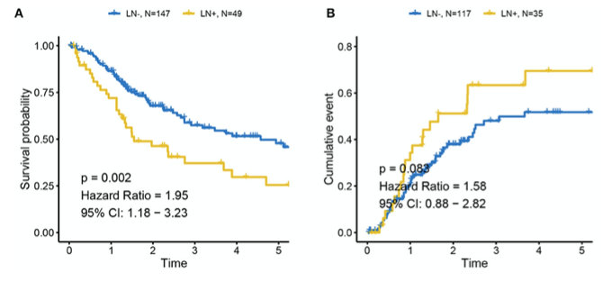

出自https://www.frontiersin.org/articles/10.3389/fonc.2019.00488/full

fromhttps://www.frontiersin.org/articles/10.3389/fonc.2019.00488/full

# 使用场景

# Usage scenario

在展示基因表达水平（连续变量）对生存期的影响时找到最佳分组，多个基因，一次出图

后面可以接`FigureYa36双因子生存分析`，对比两个基因的高低组合对预后的影响。

Find the best grouping when showing the effect of gene expression levels (continuous variables) on survival, multiple genes, one graph at a time

Later, you can take the `FigureYa36 two-factor survival analysis` to compare the effect of the combination of high and low levels of two genes on the prognosis.

# 环境设置

# Environment setting

```r
source("install_dependencies.R")
```

```
## Starting R package installation...
## ===========================================
##
## Installing CRAN packages...
## Package already installed: KMsurv
## Package already installed: survival
## Package already installed: survminer
##
## ===========================================
## Package installation completed!
## You can now run your R scripts in this directory.
```

```r
library(survival)
library(survminer)
Sys.setenv(LANGUAGE = "en") #显示英文报错信息 display English error messages
options(stringsAsFactors = FALSE) #禁止chr转成factor prohibit the conversion of chr to factor
```

# 输入数据

# Input data

第一列是生存时间、第二列是追踪情况、第三列以后是基因表达水平

The first column is survival time, the second column is follow-up status, and from the third column onwards are gene expression levels.

```r
svdata <- read.csv("easy_input.csv",header = T,row.names = 1)

dim(svdata)
```

```
## [1] 527  20
```

```r
head(svdata[1:3,1:6])
```

```
##              futime fustat    AKAP12     THBS1     PAPPA  ANKRD33B
## TCGA-A5-A2K2   9.85      0  696.4213  755.0881  23.94361 100.32920
## TCGA-AP-A0LD   9.83      0 2250.6324 3135.0809  13.36829   2.48404
## TCGA-BS-A0UA   9.58      0  734.2439 2043.6342 138.91512  76.27777
```

# 数据预处理

# Data preprocessing

找best separation用的是survminer的函数，避免无法切分数据集的情况，添加了`4和5`

Finding the best separation uses the survminer’s function to avoid the inability to slice the dataset, adding `4 and 5`

```r
pct = 0.1
# 1. 提取出表达谱
# 1. extract expression profiles
expr <- svdata[,3:ncol(svdata)]

# 2. 根据情况对表达谱做对数转换
# 2. logarithmic conversion of expression spectra as appropriate
expr <- log2(expr + 1)

# 3. 取方差大于1的基因
# 3. take genes with variance greater than 1
expr <- expr[,apply(expr, 2, sd) > 0]

# 针对报错stat(scores, x, weights = weights, pmethod, minprop, maxprop, : no data between minprop, maxprop
# 4. (关键) 取表达量为0的样本数目小于总样本数pct%的样本，这里pct默认为0.1，即10%
# in response to the error stat(scores, x, weights = weights, pmethod, minprop, maxprop, : no data between minprop, maxprop
# 4. (Key) take the number of samples where the number of samples with an expression of 0 is less than pct% of the total number of samples, where pct defaults to 0.1, i.e., 10%
expr <- expr[,apply(expr, 2, function(x) sum(x == 0) < pct * nrow(expr))]

# 针对报错Error in survdiff.fit(y, groups, strata.keep, rho) : There is only 1 group
# 5. (关键) 基因名出错会导致出现只有一个组的情况
# in response to the error Error in survdiff.fit(y, groups, strata.keep, rho) : There is only 1 group
# 5. (Key) An error in the gene name can lead to a situation where there is only 1 group
colnames(expr) <- make.names(colnames(expr))

# 6. 数据合并
# 6. data merge
svdata <- cbind.data.frame(svdata[,1:2],expr)

##对数据集的基因进行bestSeparation统计
##bestSeparation statistics for genes in a dataset
res.cut <- surv_cutpoint(svdata, time = "futime",
                         event = "fustat",
                         variables = names(svdata)[3:ncol(svdata)],
                         minprop = 0.3) #默认组内sample不能低于30% the default group sample can't be less than 30%
```

[output not shown]

```r
##按照bestSeparation分高低表达
##expressions according to bestSeparation in high and low levels
res.cat <- surv_categorize(res.cut)
```

# 统计作图

# Statistical graphing

写循环画生存曲线和事件发生率曲线。

Write loops to draw survival curves and event rate curves.

```r
my.surv <- Surv(res.cat$futime, res.cat$fustat)
pl <- pl2 <- list() # 初始化生存曲线和事件发生率曲线的列表 initialize the list of survival curves and event rate curves

# 建一个空的dataframe，用来存放统计量
# build an empty dataframe to hold the statistic
ptable <- data.frame(matrix(NA,ncol(svdata)-2,5))
colnames(ptable) <- c("ID", "pvalue", "HR", "CIlow", "CIup")

n = 0
for (i in colnames(res.cat)[3:ncol(svdata)]) {
  group <- res.cat[,i]
  survival_dat <- data.frame(group = group)
  fit <- survfit(my.surv ~ group)

  ##计算HR以及95%CI
  ##修改分组参照
  ##calculate HR and 95% CI
  ##modify subgroup references
  group <- factor(group, levels = c("low", "high"))
  data.survdiff <- survdiff(my.surv ~ group)
  p.val = 1 - pchisq(data.survdiff$chisq, length(data.survdiff$n) - 1)
  HR = (data.survdiff$obs[2]/data.survdiff$exp[2])/(data.survdiff$obs[1]/data.survdiff$exp[1])
  up95 = exp(log(HR) + qnorm(0.975)*sqrt(1/data.survdiff$exp[2]+1/data.survdiff$exp[1]))
  low95 = exp(log(HR) - qnorm(0.975)*sqrt(1/data.survdiff$exp[2]+1/data.survdiff$exp[1]))

  #如果只想输出p value<=0.05的基因，就把下面这6行放到if (p.val>0.05) next那句的后面
  #if you only want to output genes with p value <= 0.05, put the following 6 lines after the if (p.val>0.05) next sentence
  n = n + 1
  ptable$ID[n] <- i
  ptable$pvalue[n] <- p.val
  ptable$HR[n] <- HR
  ptable$CIlow[n] <- low95
  ptable$CIup[n] <- up95

  #只画出p value<=0.05的基因，如果不想筛选，就删掉下面这行
  #plot only the genes with p value <= 0.05, if you don't want to screen, delete the following line
  if (p.val>0.05) next

  HR <- paste("Hazard Ratio = ", round(HR,2), sep = "")
  CI <- paste("95% CI: ", paste(round(low95,2), round(up95,2), sep = " - "), sep = "")

  #按照基因表达量从低到高排序，便于取出分界表达量
  #sort by gene expression from low to high, easy to take out the cut-off expression
  svsort <- svdata[order(svdata[,i]),]

  # 传统生存曲线
  # traditional survival curves
  pl[[i]]<-ggsurvplot(fit, data = survival_dat ,
           #ggtheme = theme_bw(), #想要网格就运行这行 run this line if you want the grid
           conf.int = F, #不画置信区间，想画置信区间就把F改成T do not draw confidence intervals, if you want to draw confidence intervals, change F to T
           #conf.int.style = "step",#置信区间的类型，还可改为ribbon the type of confidence interval, which can also be changed to ribbon
           censor = F, #不显示观察值所在的位置 do not show the location of the observation
           palette = c("#D95F02","#1B9E77"), #线的颜色对应高、低 color of the line corresponds to high and low

           legend.title = i,#基因名写在图例题目的位置 the gene name is written in the location of the legend caption
           font.legend = 11,#图例的字体大小 legend font size
           #font.title = 12,font.x = 10,font.y = 10,#设置其他字体大小 set other font sizes

           #在图例上标出高低分界点的表达量，和组内sample数量
           #mark the expression of the high and low cutoffs on the legend, and the number of samples in the group
           legend.labs=c(paste0(">",round(svsort[fit$n[2],i],2),"(",fit$n[1],")"),
                           paste0("<",round(svsort[fit$n[2],i],2),"(",fit$n[2],")")),

           #标出pvalue、HR、95% CI
           #太小的p value标为p < 0.001
           #label pvalue, HR, 95% CI
           #too small p value labeled as p < 0.001
           pval = paste(pval = ifelse(p.val < 0.001, "p < 0.001",
                                             paste("p = ",round(p.val,3), sep = "")),
                        HR, CI, sep = "\n"))

  #每一个图保存为一个pdf文件
  #save each diagram as a pdf file
  ggsave(paste0(i,".pdf"),width = 4,height = 4)

  # 同样绘制event曲线
  # plot event curves similarly
  pl2[[i]]<-ggsurvplot(fit, data = survival_dat ,
                       fun = "event", # 曲线类型设置为event curve type is set to event
           #ggtheme = theme_bw(),
           conf.int = F,
           #conf.int.style = "step",
           censor = F,
           palette = c("#D95F02","#1B9E77"),

           legend.title = i,
           font.legend = 11,
           #font.title = 12,font.x = 10,font.y = 10,

           #在图例上标出高低分界点的表达量，和组内sample数量
           #mark the expression of the high and low cutoffs on the legend, and the number of samples in the group
           legend.labs=c(paste0(">",round(svsort[fit$n[2],i],2),"(",fit$n[1],")"),
                           paste0("<",round(svsort[fit$n[2],i],2),"(",fit$n[2],")")),

           #标出pvalue、HR、95% CI
           #太小的p value标为p < 0.001
           #label pvalue, HR, 95% CI
           #too small p value labeled as p < 0.001
           pval = paste(pval = ifelse(p.val < 0.001, "p < 0.001",
                                             paste("p = ",round(p.val,3), sep = "")),
                        HR, CI, sep = "\n"))
  #每一个图保存为一个pdf文件
  #save each diagram as a pdf file
  ggsave(paste0(i," event.pdf"),width = 4,height = 4)
}
length(pl)
```

```
## [1] 10
```

```r
# 保存到文件
# save to file
write.csv(ptable, "pvalue_output.csv", quote = F, row.names = F)
```

# 批量出图

# Batch plot

用survminer包自带的函数组图

Use the functions that come with the survminer package to group plots

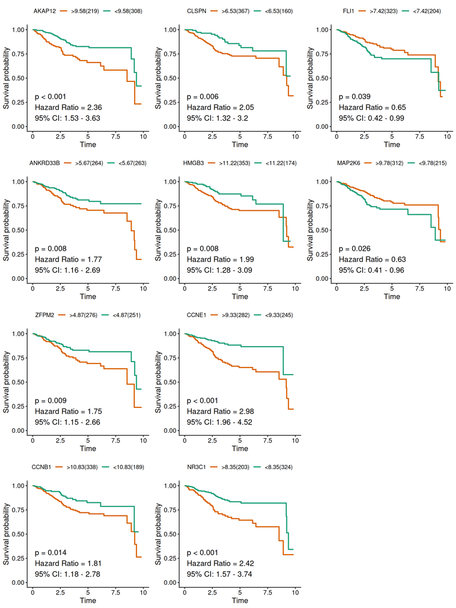

```r
# 传统生存曲线
# traditional survival curve
res <- arrange_ggsurvplots(pl,
                           print = T,
                           ncol = 3, nrow = 4)#每页纸画几列几行 how many columns and rows per page
```

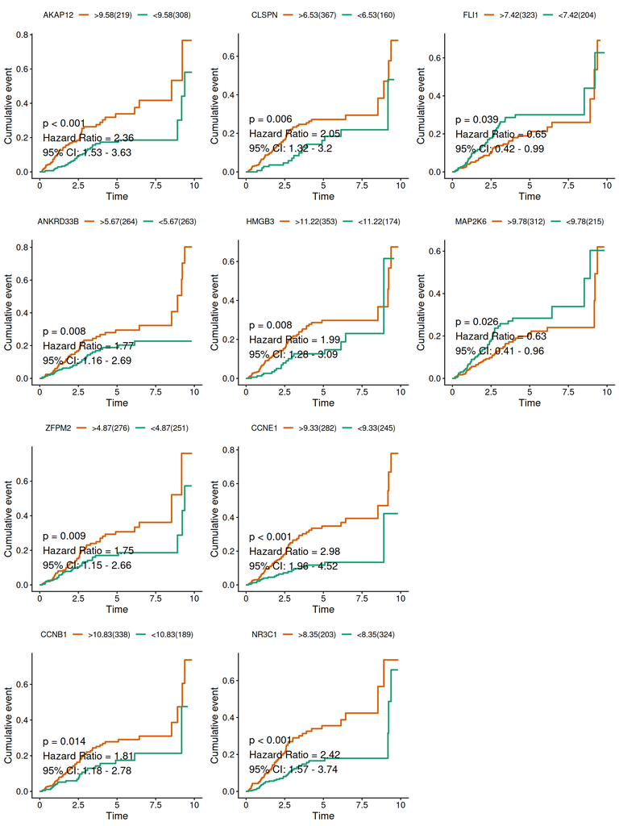

```r
#保存到pdf文件
#save to pdf file
ggsave("bestSurvPlot.pdf",res,width = 12,height = 16)

# 事件发生率曲线
# incidence rate curve
res <- arrange_ggsurvplots(pl2,
                           print = T,
                           ncol = 3, nrow = 4)#每页纸画几列几行 how many columns and rows per page
```

```r
#保存到pdf文件
#save to pdf file
ggsave("bestSurvPlot_event.pdf",res,width = 12,height = 16)
```